# Análisis de variables climáticas seleccionadas (Canarias)

2026-10-08

Análisis y validación, como dataset para el proyecto personal de **AEDV**, de las variables climáticas de Canarias generadas en CLIMA_CANARIAS_TableDatasetGeneration.Rmd. Aquí, los **datasets a evaluar son las variables climáticas**: cada variable es un atributo medido por municipio y mes. La fuente es el fichero de **histórico observado** `observaciones_canarias_1990_2022.rds` (rejilla AEMET ~2,5 km, 1990–2022). También se analiza el fichero `proyecciones_canarias.rds` de **proyecciones** hacia el futuro.

Igual que el resto de documentos de selección de datasets de la asignatura, este tiene **dos partes independientes**:

1. **Selección de variables y guardado de metadatos** — elige las variables a analizar y deja en disco su ficha (`CLIMA_CANARIAS_metadatos.xlsx`). Los datos en sí (los dos `.rds`) los genera `CLIMA_CANARIAS_TableDatasetGeneration.Rmd`, que es el que descarga los NetCDF de AdapteCCa.
2. **Análisis del dataset** — parte de esos ficheros del disco y no usa nada de la sección anterior, de modo que **se puede copiar tal cual en la memoria del proyecto**.

```r
# nombre base de los ficheros de metadatos y ficheros de datos ya generados
filename  <- "CLIMA_CANARIAS"
f_obs     <- "observaciones_canarias_1990_2022.rds"
f_proy    <- "proyecciones_canarias.rds"
```

# 1 Selección de variables y guardado de metadatos

Las variables a analizar se seleccionan por su código (`variable`):

```r
VARS <- c("tasmax", "tasmin", "tmean", "tasmaxmax", "tasminmin",
          "tasminNa20", "tasminNb0", "tasmaxNap90", "tasminNap90",
          "tasmaxhwdmax", "pr", "prNa1", "prmax24", "prmax5days")
```

A diferencia del INE, el ISTAC, EUROSTAT o el Banco Mundial, AdapteCCa **no tiene un catálogo previo** del que extraer la ficha del dataset: aquí los metadatos se construyen en este mismo documento y se guardan en `CLIMA_CANARIAS_metadatos.xlsx`, con **cuatro hojas**:

- `dataset` — la ficha general (fuente, rejilla, cobertura, tamaño de los dos ficheros).
- `variables` — el significado de cada variable climática, con su categoría y su unidad.
- `horizontes` — el periodo de 30 años que representa cada horizonte de las proyecciones.
- `escenarios` — las 4 trayectorias de emisión SSP, con su forzamiento y su calentamiento estimado.

Las tres últimas son las **explicaciones de los indicadores**, que es lo que en las otras fuentes viene ya dado en el catálogo (`Indicator_desc` en el Banco Mundial, `Descripcion` del `topic` en EUROSTAT).

> **Nota:** las descripciones han sido redactadas a partir de la documentación de AdapteCCa (variables/índices del visor) y del 6º Informe del IPCC. **No provienen literalmente de la API.** Si se cambian las variables seleccionadas, habrá que revisar/ampliar las descripciones.

```r
# DESCRIPCIÓN DE CADA VARIABLE CLIMÁTICA (columna `variable` de los dos rds)
desc_var <- tibble::tribble(
  ~variable,       ~categoria,       ~description,
  "tasmax",        "Temperatura",    "Media mensual de la temperatura máxima diaria a 2 m.",
  "tasmin",        "Temperatura",    "Media mensual de la temperatura mínima diaria a 2 m.",
  "tmean",         "Temperatura",    "Media mensual de la temperatura media diaria a 2 m.",
  "tasmaxmax",     "Temperatura",    "Máximo mensual de la temperatura máxima diaria (extremo cálido del mes).",
  "tasminmin",     "Temperatura",    "Mínimo mensual de la temperatura mínima diaria (extremo frío del mes).",
  "tasminNa20",    "Temperatura",    "Nº de días al mes con temperatura mínima > 20 °C (noches tropicales).",
  "tasminNb0",     "Temperatura",    "Nº de días al mes con temperatura mínima < 0 °C (días de helada).",
  "tasmaxNap90",   "Temperatura",    "Nº de días al mes con temperatura máxima por encima del percentil 90 (días cálidos).",
  "tasminNap90",   "Temperatura",    "Nº de días al mes con temperatura mínima por encima del percentil 90 (noches cálidas).",
  "tasmaxhwdmax",  "Temperatura",    "Duración máxima de ola de calor: días consecutivos con Tmáx > percentil 90.",
  "pr",            "Precipitación",  "Media mensual de la precipitación diaria acumulada.",
  "prNa1",         "Precipitación",  "Nº de días al mes con precipitación > 1 mm (días de lluvia).",
  "prmax24",       "Precipitación",  "Máxima precipitación mensual acumulada en 1 día (RX1day).",
  "prmax5days",    "Precipitación",  "Máxima precipitación mensual acumulada en 5 días (RX5day)."
)
```

```r
# PERIODO DE 30 AÑOS QUE REPRESENTA CADA HORIZONTE (AdapteCCa / Escenarios-PNACC)
desc_horizonte <- tibble::tribble(
  ~horizonte,      ~periodo,     ~denominacion,
  "reference",     "1971-2000",  "base histórica",
  "near_future",   "2011-2040",  "futuro cercano",
  "medium_future", "2041-2070",  "futuro medio",
  "far_future",    "2071-2100",  "futuro lejano"
)
```

```r
# LAS 4 TRAYECTORIAS DE EMISIÓN SSP (CMIP6 / IPCC-AR6).
# Nombres de columna sin espacios ni tildes para que sobrevivan al viaje por el
# xlsx; las etiquetas legibles se ponen al imprimir la tabla, más abajo.
desc_escenario <- tibble::tribble(
  ~escenario, ~SSP,       ~relato,                              ~forzamiento_2100, ~emisiones,  ~calentamiento_2100_AR6, ~description,
  "ssp126",   "SSP1-2.6", "Sostenibilidad",                     "~2,6 W/m²",       "Bajas",     "~1,8 °C (1,3–2,4)",     "CO₂ neto cero hacia ~2050. Compatible con limitar el calentamiento bien por debajo de 2 °C (Acuerdo de París).",
  "ssp245",   "SSP2-4.5", "Camino intermedio",                  "~4,5 W/m²",       "Medias",    "~2,7 °C (2,1–3,5)",     "Emisiones intermedias; las políticas climáticas avanzan a ritmo moderado. Escenario 'central' de referencia.",
  "ssp370",   "SSP3-7.0", "Rivalidad regional",                 "~7,0 W/m²",       "Altas",     "~3,6 °C (2,8–4,6)",     "Mundo fragmentado, poca cooperación climática; las emisiones de GHG casi se duplican hacia 2100.",
  "ssp585",   "SSP5-8.5", "Desarrollo por combustibles fósiles","~8,5 W/m²",       "Muy altas", "~4,4 °C (3,3–5,7)",     "Crecimiento intensivo en combustibles fósiles. Límite superior plausible de emisiones."
)
```

La ficha general y la unidad de cada variable se calculan a partir de los `.rds` ya guardados en disco, para que describan exactamente lo que hay en ellos y no lo que se esperaba generar.

```r
hist_all <- readRDS(f_obs) |> as_tibble()
proy_all <- readRDS(f_proy) |> as_tibble()

# la unidad no se escribe a mano: se lee de los propios datos
unidades <- hist_all |> distinct(variable, unidad)

variables_sel <- desc_var |>
  filter(variable %in% VARS) |>
  left_join(unidades, by = "variable") |>
  mutate(area = "MUNI", frecuencia = "Mensual") |>
  relocate(unidad, area, frecuencia, .after = categoria)

ficha <- tibble(
  Campo = c("Fuente", "Coleccion", "Ambito", "Rejilla", "Metodos.downscaling", "URL",
            "Fecha.de.generacion",
            "Fichero.observaciones", "Obs.N.filas", "Obs.N.variables",
            "Obs.N.municipios", "Obs.Freq", "Obs.Ini", "Obs.Fin", "Obs.N.periodos",
            "Fichero.proyecciones", "Proy.N.filas", "Proy.N.escenarios",
            "Proy.N.modelos", "Proy.N.horizontes", "Proy.N.meses"),
  Valor = c(
    "Visor AdapteCCa (OECC/MITECO, AEMET, CSIC y Fundación Biodiversidad)",
    "Escenarios-PNACC 2024",
    "Canarias, municipios",
    "ROCIO+_CAN (~2,5 km)",
    "ESD-RegBA (temperatura) y deepESD (precipitación)",
    "https://escenarios.adaptecca.es/",
    as.character(Sys.Date()),
    f_obs,
    as.character(nrow(hist_all)),
    as.character(n_distinct(hist_all$variable)),
    as.character(n_distinct(hist_all$municipio)),
    "M (mensual)",
    as.character(min(hist_all$fecha)),
    as.character(max(hist_all$fecha)),
    as.character(n_distinct(hist_all$fecha)),
    f_proy,
    as.character(nrow(proy_all)),
    as.character(n_distinct(proy_all$escenario)),
    as.character(n_distinct(proy_all$modelo)),
    as.character(n_distinct(proy_all$horizonte)),
    as.character(n_distinct(proy_all$mes))
  )
)

# comprobación: toda variable seleccionada tiene que existir en los datos y tener
# descripción, y todo horizonte/escenario de las proyecciones estar documentado
faltan_desc <- setdiff(VARS, desc_var$variable)
faltan_dato <- setdiff(VARS, unique(hist_all$variable))
faltan_hor  <- setdiff(unique(proy_all$horizonte), desc_horizonte$horizonte)
faltan_esc  <- setdiff(unique(proy_all$escenario), desc_escenario$escenario)
if(length(faltan_desc) > 0) warning("Variables sin descripción: ", paste(faltan_desc, collapse = ", "))
if(length(faltan_dato) > 0) warning("Variables que no están en el rds: ", paste(faltan_dato, collapse = ", "))
if(length(faltan_hor)  > 0) warning("Horizontes sin descripción: ", paste(faltan_hor, collapse = ", "))
if(length(faltan_esc)  > 0) warning("Escenarios sin descripción: ", paste(faltan_esc, collapse = ", "))

# las cuatro hojas en un solo xlsx: openxlsx toma el nombre de cada hoja del
# nombre del elemento de la lista
write.xlsx(list(dataset    = ficha,
                variables  = variables_sel,
                horizontes = desc_horizonte,
                escenarios = desc_escenario),
           file = paste0(filename, "_metadatos.xlsx"), overwrite = TRUE)

cat("Fichero guardado:", paste0(filename, "_metadatos.xlsx"),
    "- hojas: dataset, variables, horizontes, escenarios\n")
```

```
## Fichero guardado: CLIMA_CANARIAS_metadatos.xlsx - hojas: dataset, variables, horizontes, escenarios
```

```r
cat("Variables seleccionadas:", nrow(variables_sel), "de", length(VARS), "\n")
```

```
## Variables seleccionadas: 14 de 14
```

```r
cat("Elementos sin descripción:", length(faltan_desc), "variables,",
    length(faltan_hor), "horizontes,", length(faltan_esc), "escenarios\n")
```

```
## Elementos sin descripción: 0 variables, 0 horizontes, 0 escenarios
```

Una vez guardados en disco los metadatos (fichero xlsx) y estando ya los datos (los dos ficheros RDS), iniciamos el proceso de análisis. A partir de aquí el documento se compila **solo** con los ficheros ya guardados en disco; no se usa ningún objeto de la sección anterior. Es a propósito: es la parte que se incorpora a la memoria del proyecto personal (ver la última sección, *Incorporación del dataset a la memoria*), así que tiene que poder ejecutarse sola (lo único que se repite de lo definido antes son los nombres de fichero).

# 2 Análisis del dataset

**metadatos**

| Campo | Valor |
| --- | --- |
| Fuente | Visor AdapteCCa (OECC/MITECO, AEMET, CSIC y Fundación Biodiversidad) |
| Coleccion | Escenarios-PNACC 2024 |
| Ambito | Canarias, municipios |
| Rejilla | ROCIO+_CAN (~2,5 km) |
| Metodos.downscaling | ESD-RegBA (temperatura) y deepESD (precipitación) |
| URL | https://escenarios.adaptecca.es/ |
| Fecha.de.generacion | 2026-10-08 |
| Fichero.observaciones | observaciones_canarias_1990_2022.rds |
| Obs.N.filas | 487872 |
| Obs.N.variables | 14 |
| Obs.N.municipios | 88 |
| Obs.Freq | M (mensual) |
| Obs.Ini | 1990-01 |
| Obs.Fin | 2022-12 |
| Obs.N.periodos | 396 |
| Fichero.proyecciones | proyecciones_canarias.rds |
| Proy.N.filas | 2838528 |
| Proy.N.escenarios | 4 |
| Proy.N.modelos | 12 |
| Proy.N.horizontes | 4 |
| Proy.N.meses | 12 |

## 2.1 Origen de los datos: AdapteCCa

Todos los datos provienen del **Visor de Escenarios de Cambio Climático de AdapteCCa**, la plataforma oficial sobre adaptación al cambio climático en España. Pertenecen a la colección **Escenarios-PNACC** (Plan Nacional de Adaptación al Cambio Climático) y los elabora el Grupo de Trabajo de Escenarios: la **Oficina Española de Cambio Climático (OECC/MITECO)**, la **AEMET**, el **CSIC** y la **Fundación Biodiversidad**, con desarrollo técnico de la **Universidad de Cantabria (IFCA, CSIC-UC)** y **Predictia**. Los datos se distribuyen en formato NetCDF mediante un servicio **THREDDS**.

Para Canarias, AdapteCCa ofrece —por primera vez en su última actualización— datos **en rejilla de alta resolución (~2,5 km)**, tanto observados como proyectados, sobre la malla observacional **ROCIO+_CAN** de AEMET (antes solo había datos puntuales por estación). Hay dos productos bien distintos:

### 2.1.1 Observaciones: el clima registrado (1990–2022)

Es el clima **realmente medido**, sin ningún modelo climático de por medio:

- Parte de las **observaciones diarias de las estaciones de AEMET** en Canarias.
- Esos registros se **interpolan a una rejilla regular de ~2,5 km** (producto AEMET-2.5KM / ROCIO+_CAN), que cubre todo el archipiélago, también donde no hay estaciones.
- De la rejilla diaria se calculan los **agregados mensuales** que usamos (medias de temperatura, totales de precipitación, conteos de días, máximos…).
- La serie en rejilla disponible cubre **1990–2022**.

Es, por tanto, dato observado y espacializado: sirve como **línea base** real contra la que comparar el futuro.

### 2.1.2 Proyecciones: el clima simulado (siglo XXI)

Es el clima **simulado** para el futuro, y su obtención tiene dos pasos:

1. **Modelos climáticos globales CMIP6** — los mismos que sustentan el 6º Informe del IPCC (AR6). Simulan el clima del planeta para distintos escenarios de emisiones, pero con una resolución demasiado gruesa (~100 km) para unas islas pequeñas.
2. **Regionalización (downscaling) estadística** — se “baja” esa información a la rejilla de ~2,5 km con técnicas de *machine learning* que aprenden la relación entre el clima global y las observaciones de AEMET. Se usan **dos métodos** según la variable:
   - **ESD-RegBA** (desarrollado por AEMET) → variables de **temperatura**.
   - **deepESD** (desarrollado por el CSIC, basado en *deep learning*) → **precipitación** (y evapotranspiración).

El resultado son **climatologías** (medias de 30 años, no series con fecha) para los **4 escenarios de emisión SSP** × **4 horizontes**: la base histórica de referencia (**1971–2000**) y los 3 horizontes futuros (2011–2040, 2041–2070, 2071–2100), calibradas con las observaciones de AEMET. El detalle de escenarios y horizontes está más abajo, en las secciones *Proyecciones* y *Escenarios de emisión (GHG / SSP)*.

## 2.2 Variables (datasets) seleccionadas

| variable | categoría | unidad | área | frecuencia | descripción |
| --- | --- | --- | --- | --- | --- |
| tasmax | Temperatura | °C | MUNI | Mensual | Media mensual de la temperatura máxima diaria a 2 m. |
| tasmin | Temperatura | °C | MUNI | Mensual | Media mensual de la temperatura mínima diaria a 2 m. |
| tmean | Temperatura | °C | MUNI | Mensual | Media mensual de la temperatura media diaria a 2 m. |
| tasmaxmax | Temperatura | °C | MUNI | Mensual | Máximo mensual de la temperatura máxima diaria (extremo cálido del mes). |
| tasminmin | Temperatura | °C | MUNI | Mensual | Mínimo mensual de la temperatura mínima diaria (extremo frío del mes). |
| tasminNa20 | Temperatura | días | MUNI | Mensual | Nº de días al mes con temperatura mínima > 20 °C (noches tropicales). |
| tasminNb0 | Temperatura | días | MUNI | Mensual | Nº de días al mes con temperatura mínima < 0 °C (días de helada). |
| tasmaxNap90 | Temperatura | días | MUNI | Mensual | Nº de días al mes con temperatura máxima por encima del percentil 90 (días cálidos). |
| tasminNap90 | Temperatura | días | MUNI | Mensual | Nº de días al mes con temperatura mínima por encima del percentil 90 (noches cálidas). |
| tasmaxhwdmax | Temperatura | días | MUNI | Mensual | Duración máxima de ola de calor: días consecutivos con Tmáx > percentil 90. |
| pr | Precipitación | mm | MUNI | Mensual | Media mensual de la precipitación diaria acumulada. |
| prNa1 | Precipitación | días | MUNI | Mensual | Nº de días al mes con precipitación > 1 mm (días de lluvia). |
| prmax24 | Precipitación | mm | MUNI | Mensual | Máxima precipitación mensual acumulada en 1 día (RX1day). |
| prmax5days | Precipitación | mm | MUNI | Mensual | Máxima precipitación mensual acumulada en 5 días (RX5day). |

## 2.3 Datos: serie histórica observada

**data**

```
## # A tibble: 487,872 × 5
##   VARIABLE MUNICIPIO UNIDAD TIME    VALUE
##   <chr>    <chr>     <chr>  <chr>   <dbl>
## 1 pr       Adeje     mm     1990-01  0.18
## 2 pr       Adeje     mm     1990-02  0.01
## 3 pr       Adeje     mm     1990-03  2
## 4 pr       Adeje     mm     1990-04  0.54
## 5 pr       Adeje     mm     1990-05  0.07
## # ℹ 487,867 more rows
```

Muestra de las primeras 20 filas del histórico observado por municipio, variable y mes:

| VARIABLE | MUNICIPIO | UNIDAD | TIME | VALUE |
| --- | --- | --- | --- | --- |
| pr | Adeje | mm | 1990-01 | 0.18 |
| pr | Adeje | mm | 1990-02 | 0.01 |
| pr | Adeje | mm | 1990-03 | 2.00 |
| pr | Adeje | mm | 1990-04 | 0.54 |
| pr | Adeje | mm | 1990-05 | 0.07 |
| pr | Adeje | mm | 1990-06 | 0.02 |
| pr | Adeje | mm | 1990-07 | 0.00 |
| pr | Adeje | mm | 1990-08 | 0.00 |
| pr | Adeje | mm | 1990-09 | 0.35 |
| pr | Adeje | mm | 1990-10 | 0.35 |
| pr | Adeje | mm | 1990-11 | 2.49 |
| pr | Adeje | mm | 1990-12 | 2.46 |
| pr | Adeje | mm | 1991-01 | 0.00 |
| pr | Adeje | mm | 1991-02 | 1.19 |
| pr | Adeje | mm | 1991-03 | 0.63 |
| pr | Adeje | mm | 1991-04 | 0.08 |
| pr | Adeje | mm | 1991-05 | 0.00 |
| pr | Adeje | mm | 1991-06 | 0.00 |
| pr | Adeje | mm | 1991-07 | 0.00 |
| pr | Adeje | mm | 1991-08 | 0.00 |

## 2.4 Análisis de series temporales por variable

> Para que una variable **cumpla el criterio de rango temporal**, el valor de **P25** debe superar el umbral mínimo según la frecuencia: **≥ 10** para datos anuales (`Y`), **≥ 40** para trimestrales (`Q`) y **≥ 60** para mensuales (`M`). El percentil 25 (P25) es el tamaño de serie que supera el 75 % de los municipios: si P25 ≥ umbral, al menos el 75 % de los municipios cumple el rango temporal mínimo, que es el requisito de AEDV.

**Por variable**: nº de municipios, rango de fechas y percentiles del tamaño de serie temporal (periodos por municipio).

| VARIABLE | categoria | freq_obs | n_regiones | date_start | date_end | P0 | P25 | P50 | P75 | P100 |
| --- | --- | --- | --- | --- | --- | --- | --- | --- | --- | --- |
| pr | Precipitación | M | 88 | 1990-01 | 2022-12 | 396 | 396 | 396 | 396 | 396 |
| prNa1 | Precipitación | M | 88 | 1990-01 | 2022-12 | 396 | 396 | 396 | 396 | 396 |
| prmax24 | Precipitación | M | 88 | 1990-01 | 2022-12 | 396 | 396 | 396 | 396 | 396 |
| prmax5days | Precipitación | M | 88 | 1990-01 | 2022-12 | 396 | 396 | 396 | 396 | 396 |
| tasmax | Temperatura | M | 88 | 1990-01 | 2022-12 | 396 | 396 | 396 | 396 | 396 |
| tasmaxNap90 | Temperatura | M | 88 | 1990-01 | 2022-12 | 396 | 396 | 396 | 396 | 396 |
| tasmaxhwdmax | Temperatura | M | 88 | 1990-01 | 2022-12 | 396 | 396 | 396 | 396 | 396 |
| tasmaxmax | Temperatura | M | 88 | 1990-01 | 2022-12 | 396 | 396 | 396 | 396 | 396 |
| tasmin | Temperatura | M | 88 | 1990-01 | 2022-12 | 396 | 396 | 396 | 396 | 396 |
| tasminNa20 | Temperatura | M | 88 | 1990-01 | 2022-12 | 396 | 396 | 396 | 396 | 396 |
| tasminNap90 | Temperatura | M | 88 | 1990-01 | 2022-12 | 396 | 396 | 396 | 396 | 396 |
| tasminNb0 | Temperatura | M | 88 | 1990-01 | 2022-12 | 396 | 396 | 396 | 396 | 396 |
| tasminmin | Temperatura | M | 88 | 1990-01 | 2022-12 | 396 | 396 | 396 | 396 | 396 |
| tmean | Temperatura | M | 88 | 1990-01 | 2022-12 | 396 | 396 | 396 | 396 | 396 |

## 2.5 Municipios y número de observaciones

| MUNICIPIO | n_obs |
| --- | --- |
| Adeje | 5544 |
| Agaete | 5544 |
| Agulo | 5544 |
| Agüimes | 5544 |
| Alajeró | 5544 |
| Aldea de San Nicolás, La | 5544 |
| Antigua | 5544 |
| Arafo | 5544 |
| Arico | 5544 |
| Arona | 5544 |
| Arrecife | 5544 |
| Artenara | 5544 |
| Arucas | 5544 |
| Barlovento | 5544 |
| Betancuria | 5544 |
| Breña Alta | 5544 |
| Breña Baja | 5544 |
| Buenavista del Norte | 5544 |
| Candelaria | 5544 |
| Fasnia | 5544 |
| Firgas | 5544 |
| Frontera | 5544 |
| Fuencaliente de la Palma | 5544 |
| Garachico | 5544 |
| Garafía | 5544 |
| Granadilla de Abona | 5544 |
| Guancha, La | 5544 |
| Guía de Isora | 5544 |
| Gáldar | 5544 |
| Güímar | 5544 |

[output cut: 58 more lines]

## 2.6 Validación de requisitos AEDV

**Validación de requisitos AEDV** — umbrales: > 80 municipios, último dato ≥ 2024, P25 ≥ 60 meses.

| Variable | Cobertura geográfica | Datos actualizados (≥ 2024) | Tamaño series (P25 ≥ umbral) | CUMPLE LOS 3 |
| --- | --- | --- | --- | --- |
| pr [M] | ✔ | ✘ | ✔ | ✘ |
| prNa1 [M] | ✔ | ✘ | ✔ | ✘ |
| prmax24 [M] | ✔ | ✘ | ✔ | ✘ |
| prmax5days [M] | ✔ | ✘ | ✔ | ✘ |
| tasmax [M] | ✔ | ✘ | ✔ | ✘ |
| tasmaxNap90 [M] | ✔ | ✘ | ✔ | ✘ |
| tasmaxhwdmax [M] | ✔ | ✘ | ✔ | ✘ |
| tasmaxmax [M] | ✔ | ✘ | ✔ | ✘ |
| tasmin [M] | ✔ | ✘ | ✔ | ✘ |
| tasminNa20 [M] | ✔ | ✘ | ✔ | ✘ |
| tasminNap90 [M] | ✔ | ✘ | ✔ | ✘ |
| tasminNb0 [M] | ✔ | ✘ | ✔ | ✘ |
| tasminmin [M] | ✔ | ✘ | ✔ | ✘ |
| tmean [M] | ✔ | ✘ | ✔ | ✘ |

De las **14** variables seleccionadas: **14** cumplen la **cobertura geográfica** (> 80 municipios), **14** el **tamaño de serie temporal** (P25 ≥ 60 meses) y **0** la **actualización** (último dato ≥ 2024).

> **Limitación de la fuente (importante para la conclusión):** el producto observado en rejilla de AdapteCCa llega hasta **2022** (es una colección por versión —Escenarios-PNACC 2024—, no una serie que se actualice cada año). Por eso, con el umbral estricto `anio_min = 2024` el criterio de “datos actualizados” **no se cumple** para ninguna variable; sin embargo, dado que la cobertura y la longitud temporal son excelentes (88 municipios, 396 meses por municipio, 1990–2022), podremos usar este dataset para el proyecto personal de AEDV.

## 2.7 Proyecciones (proyecciones_canarias.rds)

El segundo dataset, `proyecciones_canarias.rds`, es el **complemento prospectivo** del histórico: las mismas 14 variables, pero proyectadas al futuro con modelos CMIP6 regionalizados. Se diferencia del histórico en su estructura temporal:

- **No tiene serie anual ni fechas**: son **climatologías** (un valor por mes), así que la dimensión temporal son los 12 meses, no años. Cada valor es la **media climatológica de 30 años** del horizonte correspondiente.
- Añade tres dimensiones: **`escenario`** (4 trayectorias de emisión SSP: `ssp126`, `ssp245`, `ssp370`, `ssp585`), **`modelo`** (los 11 GCMs de CMIP6 individuales más `ensemble`, la media del conjunto) y **`horizonte`** (4 ventanas climáticas de 30 años: la base histórica de referencia y 3 horizontes futuros).
- Columnas: `municipio · variable · unidad · escenario · modelo · horizonte · mes · value`.

Los **horizontes** corresponden a estos periodos de 30 años, según la definición de AdapteCCa / Escenarios-PNACC:

| horizonte | periodo (años) | denominación |
| --- | --- | --- |
| reference | 1971-2000 | base histórica |
| near_future | 2011-2040 | futuro cercano |
| medium_future | 2041-2070 | futuro medio |
| far_future | 2071-2100 | futuro lejano |

La **línea base de referencia** del modelo es el periodo histórico **1971–2000** (código interno `reference`). **Sí** se incluye en este rds, junto a los 3 horizontes futuros, lo que permite calcular directamente las anomalías futuro − referencia. Al proceder del forzamiento histórico común de CMIP6, su valor es prácticamente idéntico en los 4 escenarios SSP (se repite en cada uno por simetría de la estructura).

Los **escenarios** son trayectorias **SSP** (*Shared Socioeconomic Pathways*) del IPCC-AR6: cada una combina un relato socioeconómico (SSP1–5) con un nivel de **forzamiento radiativo** en 2100 —el número del código, p. ej. `2.6` = 2,6 W/m²— que resume el volumen de emisiones de gases de efecto invernadero (GHG). Van de menos a más emisiones: `ssp126` (bajas) → `ssp245` (medias) → `ssp370` (altas) → `ssp585` (muy altas). A mayor escenario, mayor calentamiento proyectado. El detalle de cada uno está en la tabla de la sección *Escenarios de emisión (GHG / SSP)*.

Por eso los criterios AEDV de *series temporales* y *actualización* no aplican igual (no es una serie observada): su papel es **proyectar/comparar** frente a la línea base histórica ya validada. A continuación, un resumen de su contenido:

| Concepto | Valor |
| --- | --- |
| Variables | 14 |
| Escenarios (SSP) | ssp126, ssp245, ssp370, ssp585 |
| Modelos (GCM + ensemble) | 12 |
| Horizontes (periodo) | reference (1971-2000); near_future (2011-2040); medium_future (2041-2070); far_future (2071-2100) |
| Municipios | 88 |
| Meses | 12 |
| Filas totales | 2.838.528 |

## 2.8 Escenarios de emisión (GHG / SSP)

Detalle de las 4 trayectorias SSP presentes en el dataset de proyecciones.

**Qué significa la columna “Calentamiento 2100 (AR6)”.** Es el aumento estimado de la **temperatura media GLOBAL** del planeta a finales de siglo (media del periodo **2081–2100**) respecto al **clima preindustrial** (referencia **1850–1900**), según el **6º Informe de Evaluación del IPCC (AR6, Grupo de Trabajo I, 2021)**. Es una cifra de referencia que sitúa la severidad de cada escenario; **no** es el calentamiento concreto de Canarias —ese se obtiene de los datos regionalizados de este mismo dataset y suele diferir del valor global.

**Cómo se obtiene.** El IPCC parte del conjunto de modelos climáticos globales **CMIP6** y, combinándolos con el calentamiento ya observado, el paleoclima y el conocimiento de los procesos físicos, *acota* la dispersión de los modelos para dar, en cada escenario:

- una **mejor estimación** (el valor central), y
- un **rango “muy probable”** (entre paréntesis) que, en el lenguaje calibrado del IPCC, cubre del **percentil 5 al 95** (≈ 90 % de probabilidad).

Así, `ssp585` → *~4,4 °C (3,3–5,7)* se lee: la mejor estimación es **+4,4 °C** y es muy probable que el calentamiento global en 2100 quede **entre +3,3 y +5,7 °C**.

| Escenario | SSP | Relato | Forzamiento 2100 | Emisiones | Calentamiento 2100 (AR6) | Descripción |
| --- | --- | --- | --- | --- | --- | --- |
| ssp126 | SSP1-2.6 | Sostenibilidad | ~2,6 W/m² | Bajas | ~1,8 °C (1,3–2,4) | CO₂ neto cero hacia ~2050. Compatible con limitar el calentamiento bien por debajo de 2 °C (Acuerdo de París). |
| ssp245 | SSP2-4.5 | Camino intermedio | ~4,5 W/m² | Medias | ~2,7 °C (2,1–3,5) | Emisiones intermedias; las políticas climáticas avanzan a ritmo moderado. Escenario ‘central’ de referencia. |
| ssp370 | SSP3-7.0 | Rivalidad regional | ~7,0 W/m² | Altas | ~3,6 °C (2,8–4,6) | Mundo fragmentado, poca cooperación climática; las emisiones de GHG casi se duplican hacia 2100. |
| ssp585 | SSP5-8.5 | Desarrollo por combustibles fósiles | ~8,5 W/m² | Muy altas | ~4,4 °C (3,3–5,7) | Crecimiento intensivo en combustibles fósiles. Límite superior plausible de emisiones. |

## 2.9 Mapas coropléticos interactivos

Mapas **interactivos** (`leaflet`: zoom, *hover* con el valor y leyenda) a nivel de municipio, **sin mapa base**, con la geometría de `mapSpain`. Unen los datos por el **nombre del municipio**.

**Tmáx media de julio observada por municipio (histórico):**

[interactive chart not shown]

**Tmáx media de julio proyectada — SSP5-8.5, futuro lejano (2071–2100):**

[interactive chart not shown]

**Proyecciones por modelo (dispersión inter-modelo):** el mapa anterior usa el `ensemble` (la media de los 11 GCMs), pero el dataset guarda **cada modelo por separado**. Para el mismo caso (tasmax de julio, SSP5-8.5, futuro lejano), promediando a toda Canarias, el valor varía notablemente según el modelo; el `ensemble` (rojo) es la media del conjunto.

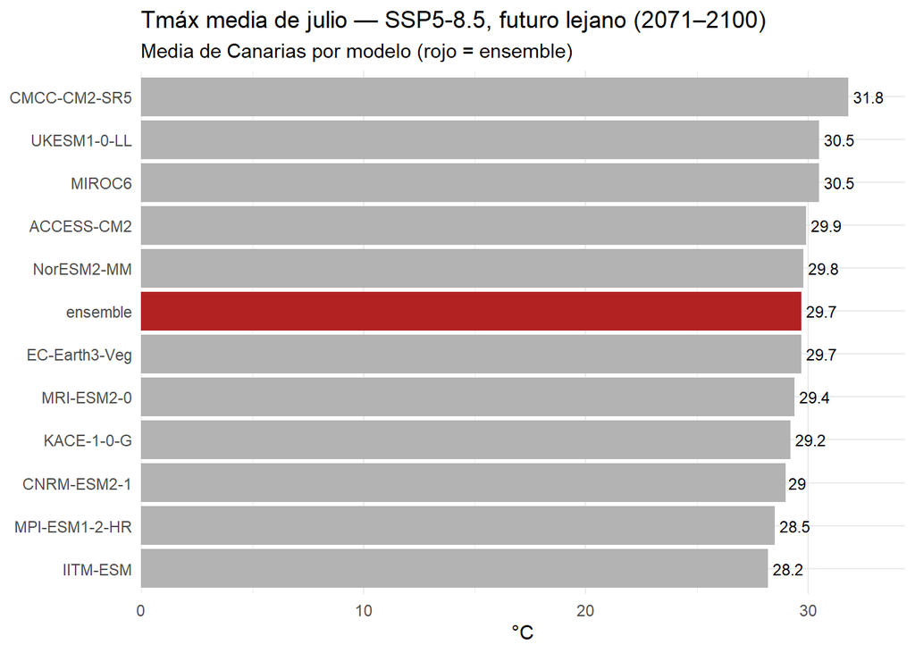

Series temporales por horizonte de cada modelo (tasmax, SSP5-8.5), promediadas a toda Canarias: cada línea gris es un GCM y la roja el `ensemble`.

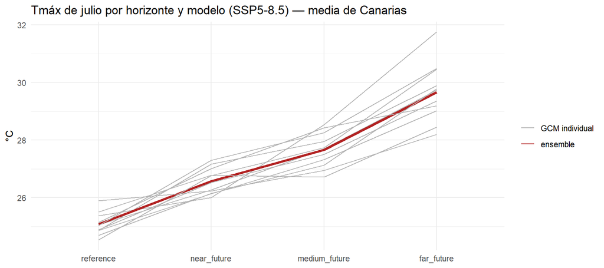

# 3 Incorporación del dataset a la memoria

Al compilar este documento se ha generado el fichero **`CLIMA_CANARIAS_analisis.Rmd`**: es la sección *Análisis del dataset* de arriba, preparada para la sección **Comprensión de los datos** de la memoria, con los títulos al nivel de esa sección. Para incorporar el dataset a la memoria:

1. Copia a la carpeta de la memoria estos ficheros de la carpeta `CLIMA_CANARIAS`: `observaciones_canarias_1990_2022.rds`, `proyecciones_canarias.rds`, `CLIMA_CANARIAS_metadatos.xlsx` y `CLIMA_CANARIAS_analisis.Rmd`.
2. Comprueba que en la carpeta de la memoria está también `utilidades.R` (viene en la carpeta `ProyectoPersonal`, junto al modelo de memoria) y que la memoria lo carga en el chunk de librerías: `source("utilidades.R")`.
3. Pega este chunk en la sección *Comprensión de los datos* de la memoria, cambiando los nombres de las tablas por otros que describan el dataset:

````
```{r, results='asis', cache=FALSE}
clima <- aedv_incluir_dataset("CLIMA_CANARIAS_analisis.Rmd")
# este dataset tiene 2 tablas: aedv_incluir_dataset() las devuelve en una lista
clima_obs  <- clima$data  # observaciones mensuales por municipio, 1990-2022
clima_proy <- clima$proy  # proyecciones por escenario, modelo y horizonte
```
````

Al compilar la memoria, el análisis aparece en el lugar del chunk y los datos quedan en las tablas `clima_obs` y `clima_proy` (tibbles), con las que se sigue trabajando en el resto de la memoria. Este dataset tiene 2 tablas: `aedv_incluir_dataset()` las devuelve juntas en una lista, y las líneas que siguen a la llamada las separan, cada una con su nombre. Si incorporas varios datasets, pega un chunk por cada uno, con nombres de tabla distintos. En un dataset auxiliar, que no tiene que cumplir los requisitos de AEDV, `aedv_incluir_dataset("CLIMA_CANARIAS_analisis.Rmd", validacion = FALSE)` omite la validación.

El texto explicativo del dataset (qué mide, qué significa cada variable y cada una de sus opciones…) se escribe en la memoria, antes o después del chunk, no en `CLIMA_CANARIAS_analisis.Rmd`: ese fichero se sustituye cada vez que se vuelve a generar.